# Ch 15 exercises

The aim of these exercises is to get experience with multivariate data sets. In this chapter’s, you’ll focus on analyses based on dissimilarities/distances.

In earlier chapters, we’ve used the sequence we’ve used previously as a guide to working through an analysis, but for this chapter and the next, this sequence doesn’t work as well, particularly step 3. Keep using the sequence, but skip over steps that aren’t appropriate for a particular question.

1. What is the biological question?
2. Is the predictor continuous or categorical?
3. Write out the linear model corresponding to this question.
4. What distribution do you expect the response variable to follow?
5. What are the assumptions behind the statistical model you’ll fit?
   1. Are those assumptions satisfied?
6. Fit the model
   1. How will you assess whether the model fits well?
   2. Can you detect an effect of the predictor?
   3. How do you measure the effect?
7. What do you conclude (including any cautions)

## A Unconstrained multivariate analysis: PCA and Principal Components Regression

Posthumus, Koprowski, and Steidl (2015) were interested in the ecological role of red squirrels in eastern North America. These territorial animals hoard pine cones for food, and create large middens - piles of plant debris - when they return to eat these pine cones, etc (see their Figure 1). These middens are potentially important habitat changes for other vertebrates of these forests. Postumus and colleagues focused on two aspects of this relationship:

How do middens influence birds and other mammals? What habitat conditions influence the use of a site by squirrels?

The data are available as Supplementary file S1. It’s an Excel file, from which you will need the first sheet (Habitat and Squirrel Features), and when you read it in, skip the first 3 rows. The package *readxl* makes this import easy. You might also want to rename the variables to something a bit more tractable. As usual, we’ve a tidied version of the file that can be used.

```r
posthumus <- read_csv("data/posthumus.csv")
head(posthumus,10)
```

| cancov | shannon | logvol | lsnags | ltrees | basarea | slope | aspect | rspres | coneind | resprop |
| --- | --- | --- | --- | --- | --- | --- | --- | --- | --- | --- |
| 78.468 | 0.623 | 101.76 | 21.93 | 131.58 | 455417.68 | -10 | 285 | 0 | 0 | 0.28571 |
| 56.716 | 0.708 | 117.46 | 21.93 | 87.72 | 305798.28 | -8 | 240 | 0 | 0 | 0.00000 |
| 83.876 | 0.381 | 31.10 | 0.00 | 87.72 | 528041.94 | -22 | 5 | 0 | 0 | 0.66667 |
| 78.208 | 1.100 | 44.34 | 21.93 | 175.44 | 636344.78 | -5 | 180 | 1 | 4 | 0.90476 |
| 58.500 | 0.892 | 153.97 | 0.00 | 21.93 | 319287.64 | -14 | 250 | 0 | 0 | 0.09524 |
| 71.708 | 0.861 | 101.45 | 0.00 | 43.86 | 520032.01 | -12 | 50 | 0 | 0 | 0.04762 |
| 65.104 | 0.699 | 124.52 | 21.93 | 109.65 | 584454.89 | -10 | 220 | 0 | 0 | 0.76190 |
| 62.348 | 0.814 | 173.77 | 0.00 | 65.79 | 440843.22 | -4 | 282 | 1 | 1 | 0.57143 |
| 65.832 | 1.017 | 74.45 | 21.93 | 43.86 | 628072.79 | -8 | 300 | 0 | 0 | 0.00000 |
| 73.164 | 0.248 | 92.94 | 65.79 | 131.58 | 928825.19 | -14 | 274 | 0 | 0 | 0.76190 |

```r
summary(posthumus)
```

```
     cancov            shannon            logvol              lsnags             ltrees             basarea              slope           aspect           rspres       coneind
 Min.   :16.64000   Min.   :0.24800   Min.   : 13.95000   Min.   :  0.0000   Min.   :  21.9300   Min.   : 187270.6   Min.   :-41.0   Min.   :  3.00   Min.   :0.0   Min.   :0.00
 1st Qu.:68.21100   1st Qu.:0.79525   1st Qu.: 48.73250   1st Qu.:  0.0000   1st Qu.: 109.6500   1st Qu.: 509582.0   1st Qu.:-18.0   1st Qu.:127.75   1st Qu.:0.0   1st Qu.:0.00
 Median :75.13000   Median :0.97650   Median : 67.88600   Median : 21.9300   Median : 230.2650   Median : 607795.4   Median :-12.0   Median :252.00   Median :0.0   Median :0.00
 Mean   :72.52511   Mean   :0.96874   Mean   : 83.13583   Mean   : 30.2634   Mean   : 464.6967   Mean   : 645351.5   Mean   :-13.7   Mean   :213.78   Mean   :0.2   Mean   :0.69
 3rd Qu.:81.08250   3rd Qu.:1.16425   3rd Qu.:110.12625   3rd Qu.: 43.8600   3rd Qu.: 794.9625   3rd Qu.: 779580.4   3rd Qu.: -8.0   3rd Qu.:310.50   3rd Qu.:0.0   3rd Qu.:0.00
 Max.   :90.89600   Max.   :1.64000   Max.   :320.77000   Max.   :131.5800   Max.   :1907.9100   Max.   :1722516.6   Max.   : -2.0   Max.   :359.00   Max.   :1.0   Max.   :4.00
    resprop
 Min.   :0.0000000
 1st Qu.:0.0000000
 Median :0.1666700
 Mean   :0.3278341
 3rd Qu.:0.6666700
 Max.   :1.0000000
```

```r
# correlation matrix - correlations low
cor(posthumus[,c('cancov','shannon','logvol','lsnags','ltrees','basarea','slope','aspect')])
```

```
                cancov         shannon         logvol          lsnags          ltrees        basarea           slope         aspect
cancov   1.00000000000 -0.221248775548 -0.31355637623  0.048869189289  0.403682264342  0.44989086535  0.029071491424 -0.13755352126
shannon -0.22124877555  1.000000000000  0.04018764355  0.138911782037 -0.259423437318  0.09926708771 -0.009026509133  0.09601412625
logvol  -0.31355637623  0.040187643552  1.00000000000  0.021759488652 -0.043456584161 -0.14381035610  0.203029710531  0.07617263547
lsnags   0.04886918929  0.138911782037  0.02175948865  1.000000000000  0.003282012157  0.51892455670 -0.163293433958  0.15753861604
ltrees   0.40368226434 -0.259423437318 -0.04345658416  0.003282012157  1.000000000000  0.11539373367 -0.034250150688  0.01161385200
basarea  0.44989086535  0.099267087710 -0.14381035610  0.518924556699  0.115393733665  1.00000000000 -0.153839072242 -0.05530764598
slope    0.02907149142 -0.009026509133  0.20302971053 -0.163293433958 -0.034250150688 -0.15383907224  1.000000000000  0.07750171696
aspect  -0.13755352126  0.096014126252  0.07617263547  0.157538616039  0.011613852003 -0.05530764598  0.077501716959  1.00000000000
```

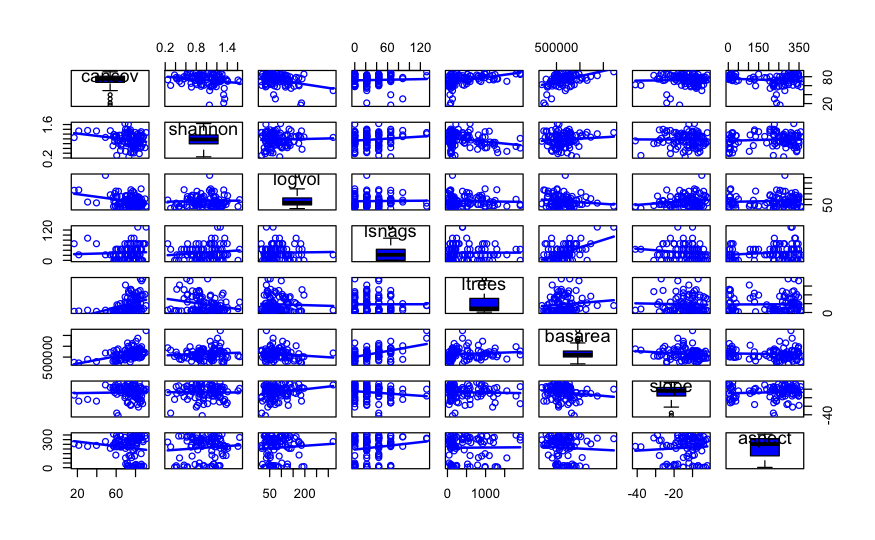

```r
scatterplotMatrix(~cancov+shannon+logvol+lsnags+ltrees+basarea+slope+aspect,data=posthumus,smooth = FALSE, diagonal=list(method='boxplot'))
```

Let’s transform the habitat variables, as was done in the original paper, and look at the scatterplot matrix again. Canopy cover was squared, and the other 5 were log-transformed. Note that the slope values in the original data file are negative, so we reversed the sign before transforming. Large snags has zero values, so we’ll add 1 to these values (1 being the smallest possible value)

```r
# transform as in original paper

posthumus <-posthumus %>%
  dplyr::mutate(
    llogvol = log10(logvol),
    llsnags = log10(lsnags+1),
    lltrees = log10(ltrees),
    lbasarea = log10(basarea),
    lslope = log10(-1*slope),
    scancov = (cancov^2)
    )
```

Relook at correlations

```r
cor(posthumus[,c('scancov','shannon','llogvol','llsnags','lltrees','lbasarea','lslope','aspect')])
```

```
                scancov        shannon         llogvol       llsnags         lltrees       lbasarea         lslope          aspect
scancov   1.00000000000 -0.21123659247 -0.205671150164 0.04219616787  0.483626339647  0.52857280932  0.03581866620 -0.141102708615
shannon  -0.21123659247  1.00000000000  0.029157265562 0.06251861796 -0.157744470176  0.04163735299  0.04122565034  0.096014126252
llogvol  -0.20567115016  0.02915726556  1.000000000000 0.10576105384 -0.005254379608 -0.13116006128 -0.19877262209  0.088040667938
llsnags   0.04219616787  0.06251861796  0.105761053839 1.00000000000  0.096833086155  0.33998513419  0.22144833115  0.126800254496
lltrees   0.48362633965 -0.15774447018 -0.005254379608 0.09683308615  1.000000000000  0.25687141012  0.03935663455  0.006370239032
lbasarea  0.52857280932  0.04163735299 -0.131160061281 0.33998513419  0.256871410122  1.00000000000  0.15031819688 -0.108194103122
lslope    0.03581866620  0.04122565034 -0.198772622093 0.22144833115  0.039356634547  0.15031819688  1.00000000000 -0.041692492151
aspect   -0.14110270862  0.09601412625  0.088040667938 0.12680025450  0.006370239032 -0.10819410312 -0.04169249215  1.000000000000
```

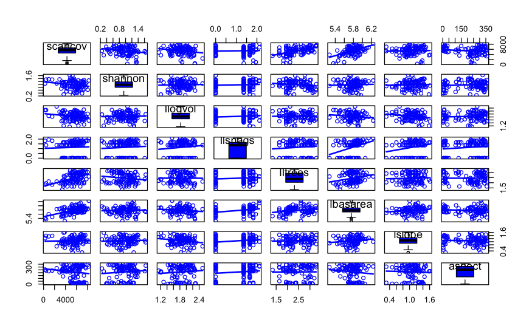

```r
scatterplotMatrix(~scancov+shannon+llogvol+llsnags+lltrees+lbasarea+lslope+aspect,data=posthumus, smooth = FALSE, diagonal=list(method='boxplot'))
```

> Curvilinear aspect has been removed by the transformations.

### Use a PCA to simplify the habitat variables

**Would you use a correlation or a covariance matrix**

> Correlation for these data

```r
# do pca on correlation matrix with princomp
posthumus.rda <- rda(posthumus[,c('scancov','shannon','llogvol','llsnags','lltrees','lbasarea','lslope','aspect')],scale=TRUE)
summary(posthumus.rda)
```

```
Call:
rda(X = posthumus[, c("scancov", "shannon", "llogvol", "llsnags",      "lltrees", "lbasarea", "lslope", "aspect")], scale = TRUE)

Partitioning of correlations:
              Inertia Proportion
Total               8          1
Unconstrained       8          1

Eigenvalues, and their contribution to the correlations

Importance of components:
                            PC1       PC2       PC3       PC4       PC5        PC6        PC7        PC8
Eigenvalue            2.0578693 1.3623096 1.1912046 0.9266121 0.9019649 0.71510351 0.52128485 0.32365114
Proportion Explained  0.2572337 0.1702887 0.1489006 0.1158265 0.1127456 0.08938794 0.06516061 0.04045639
Cumulative Proportion 0.2572337 0.4275224 0.5764229 0.6922494 0.8049951 0.89438300 0.95954361 1.00000000

Scaling 2 for species and site scores
* Species are scaled proportional to eigenvalues
* Sites are unscaled: weighted dispersion equal on all dimensions
* General scaling constant of scores:  5.304950005


Species scores

                PC1        PC2          PC3         PC4        PC5         PC6
scancov  -1.5552150  0.4820220  0.199072875  0.07719167 -0.3446836 -0.05460346
shannon   0.4257595 -1.0141155 -0.361298247  0.82003336 -1.0589109  0.58108982
llogvol   0.5686430 -0.3206417  1.313161315  0.61062355  0.6678874  0.47371758
llsnags  -0.6179940 -1.3652067  0.356712165  0.03066574  0.5996905 -0.50705720
lltrees  -1.2001923  0.2745121  0.753648179 -0.32443677 -0.2002817  0.93037522
lbasarea -1.4358953 -0.4915700 -0.007518255  0.57496756 -0.2175883 -0.47831141
lslope   -0.5359465 -0.8121112 -1.009631837 -0.61212581  0.6511139  0.73639814
aspect    0.3800855 -0.7671050  0.762386089 -1.18189983 -0.7846877 -0.23827556


Site scores (weighted sums of species scores)

               PC1         PC2          PC3         PC4         PC5          PC6
sit1    0.15751828  0.15311255  0.393704027 -0.40938794  0.43778722 -0.470706767
sit2    0.85994508  0.09833810  0.308493553 -0.27423656  0.69977522 -0.328759291
```

[output cut: 83 more lines]

```
sit86  -0.40164940 -0.79711460  0.689707890  0.13868868  0.01502566  0.105316490
sit87  -0.57548271  0.81828379 -0.198073355  0.19123216  0.20964947 -0.410765246
sit88  -0.31003890  1.06129977 -0.433245028 -0.22893764  0.54451754  0.733987121
sit89  -0.24776130  0.50640242  0.785082975  0.48170625  1.17156023  0.426330840
sit90  -0.94332051 -0.08155880 -0.089097372  0.43784373  0.81046660  0.623410630
sit91  -0.49573571 -0.46300682  0.205764637 -0.14627672 -0.42128206  0.098843642
sit92  -0.55064601  0.32660645 -0.116059924 -0.71148953 -0.60028974  1.229568699
sit93   0.06535462  1.13837679 -0.295713456  0.63930150 -0.49976757  0.080538391
sit94  -0.19178911 -0.68254980 -0.968894687 -0.49312297  0.39934870 -0.247424589
sit95   0.27018449  0.01529478 -0.724650605  0.25488294 -1.26644635  0.583139041
sit96   1.01403993 -0.88687860 -0.645382766 -0.24225382  0.40441590  0.345278833
sit97  -0.15792846 -0.92718001 -0.270149311  0.26283872 -0.04976746  0.482037825
sit98   0.47819010  0.32289300 -0.348833106 -0.83977422 -0.86223378  0.611600948
sit99   1.43208904 -0.81081174 -0.158063626 -0.09119618  0.73533412  1.022558301
sit100  0.93017387  0.73425192  0.093642709 -0.86841039 -0.27730929  0.680129874
```

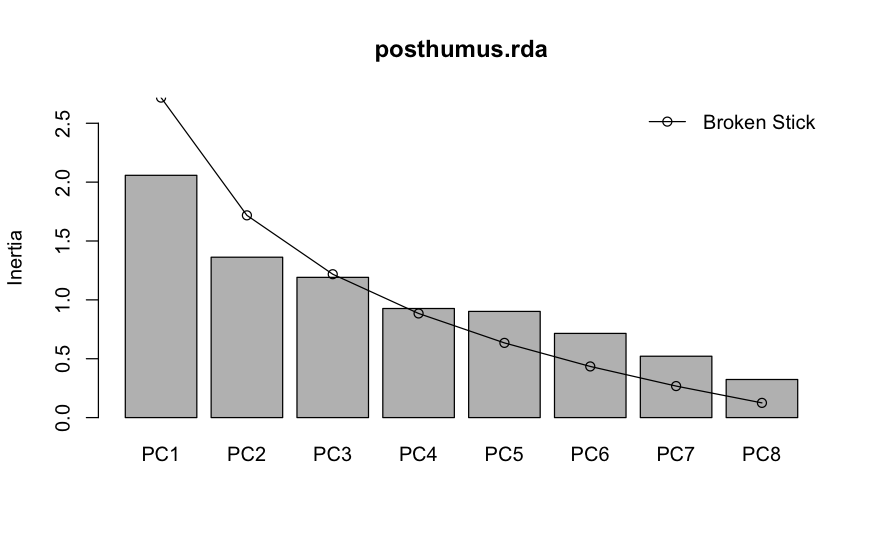

```r
screeplot(posthumus.rda,bstick=TRUE, bst.col="black",xlab = "Component", ylab = "Inertia",)
```

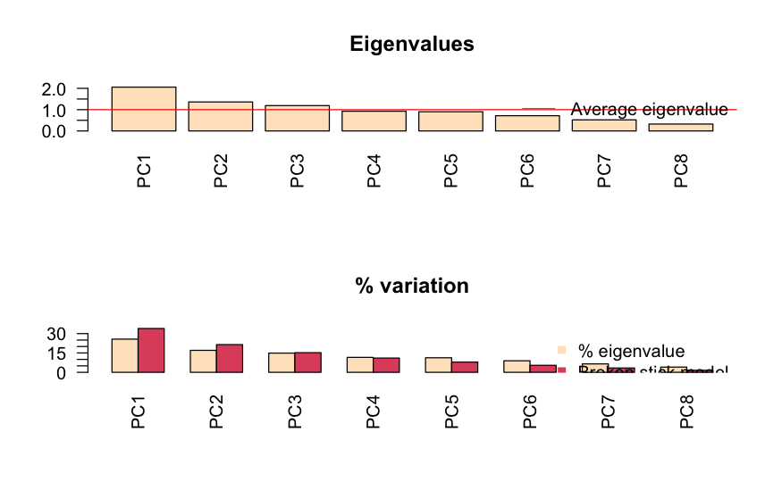

```r
#Add broken stick plot
posthumus.eig <- posthumus.rda$CA$eig
source ('http://www.davidzeleny.net/anadat-r/doku.php/en:numecolr:evplot?do=export_code&codeblock=1')
evplot(posthumus.eig)
```

**Does the PCA help with simplifying the habitat variables?**

#### Summarize the first three PCs: How much variation do they explain? How do the original variables contribute to these components?

> PC1 accounts for 26% and PC2 another 17, and PC3 another 15, then there’s a steady drop-off The keen students might produce a broken stick plot PC1 seems linked to big trees - number, basal area, and total cover PC2 seems negatively correlated with tree diversity and large snags, and perhaps steeper slope and aspect PC3 reflects more logs and large trees, reduced slope, and aspect

> Note: these loadings seem different from those in the original paper. Might want to go back and check.

### Does this matter for squirrels?

While recording habitat variables, each location was also surveyed 21 times, and the research team recorded the number of times Red Squirrels were present. With standardised surveying effort, we could look at the number of surveys with squirrels, but they also calculated a proportion of surveys with squirrels present (resprop).

Now that you have some nice independent predictors (we hope ;-)), you can explore whether squirrel presence can be predicted using them. This should be quick, as you know the predictors are independent!

Hint: If you saved your PCA analysis into a file, you can easily access the scores. If you coerce them into a dataframe, using as.data.frame(posthumus.pca$scores), you’re good to go.

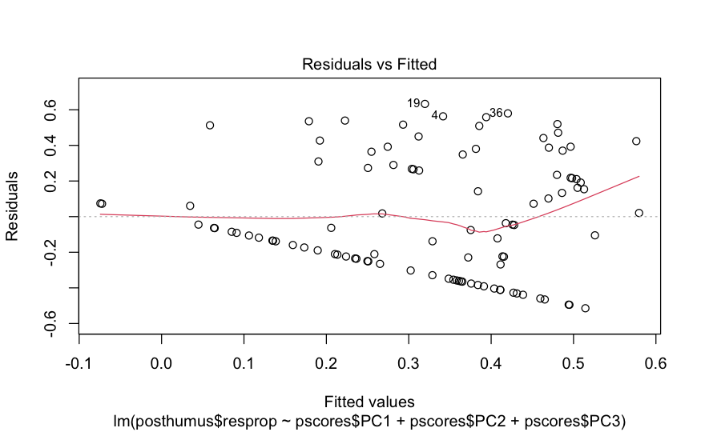

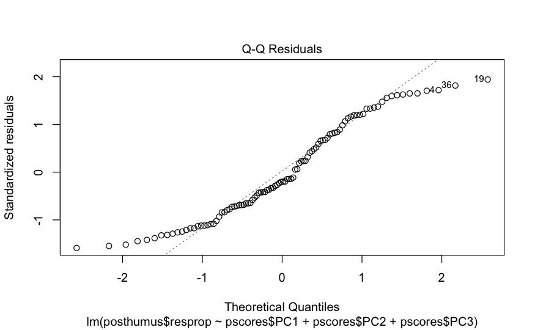

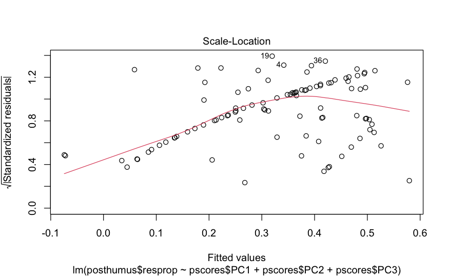

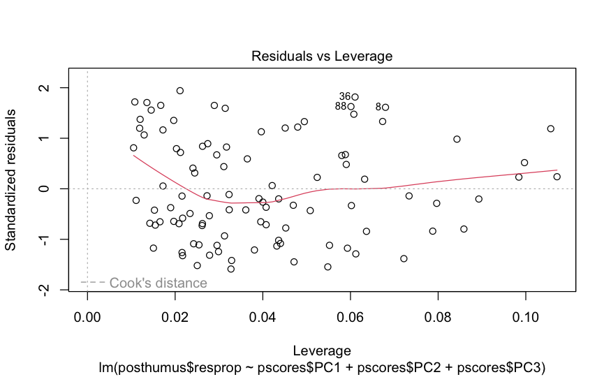

```r
pscores <-as.data.frame(posthumus.rda$CA$u)
posthumus.lm <- lm(posthumus$resprop ~ pscores$PC1 + pscores$PC2 +  pscores$PC3)
plot(posthumus.lm)
```

```r
summary(posthumus.lm)
```

```
Call:
lm(formula = posthumus$resprop ~ pscores$PC1 + pscores$PC2 +
    pscores$PC3)

Residuals:
        Min          1Q      Median          3Q         Max
-0.51439750 -0.25006979 -0.06404456  0.26911690  0.63273715

Coefficients:
               Estimate  Std. Error  t value   Pr(>|t|)
(Intercept)  0.32783410  0.03294286  9.95160 < 2.22e-16 ***
pscores$PC1 -1.40301498  0.32942861 -4.25893 4.7908e-05 ***
pscores$PC2  0.21757537  0.32942861  0.66046    0.51054
pscores$PC3 -0.33188741  0.32942861 -1.00746    0.31624
---
Signif. codes:  0 ‘***’ 0.001 ‘**’ 0.01 ‘*’ 0.05 ‘.’ 0.1 ‘ ’ 1

Residual standard error: 0.3294286 on 96 degrees of freedom
Multiple R-squared:  0.1694763, Adjusted R-squared:  0.1435225
F-statistic: 6.529907 on 3 and 96 DF,  p-value: 0.0004572917
```

```r
anova(posthumus.lm)
```

```
Analysis of Variance Table

Response: posthumus$resprop
            Df     Sum Sq    Mean Sq  F value     Pr(>F)
pscores$PC1  1  1.9684510 1.96845104 18.13853 4.7908e-05 ***
pscores$PC2  1  0.0473390 0.04733904  0.43621    0.51054
pscores$PC3  1  0.1101493 0.11014925  1.01498    0.31624
Residuals   96 10.4182278 0.10852321
---
Signif. codes:  0 ‘***’ 0.001 ‘**’ 0.01 ‘*’ 0.05 ‘.’ 0.1 ‘ ’ 1
```

> Interesting residual pattern and scatterplot - lots of zeroes in data. Suggests we may be better off using a glm or one of the techniques for overdispersed data.

## B Constrained multivariate analysis: RDA

Hutto and Barrett (2021) were concerned with effects of urbanization and the potential for urgan open spaces to mediate those effects. They focused on amphibians as a group of concern, and surveyed 51 ponds in South Carolina, where they recorded a suite of habitat variables relevant to amphibians. The sites were classified into three groups, highly urbanized, low urbanization, and urban open spaces.

At each pond, they also characterized the frog and toad assemblage, using a mixture of dip-net surveys, calls, and deployment of retreats for tree frogs.

The data are in three supplementary files, linked through the paper. You’ll be using huttoenv.csv and huttoamph.

```r
huttoenv <- read_csv("data/huttoenv.csv")
head(huttoenv, 10)
```

| site | type | group | ph | cond | wdepth | omdepth | cancov | area | rivernear | wetlandnear |
| --- | --- | --- | --- | --- | --- | --- | --- | --- | --- | --- |
| 1 | Low | 1 | 6.54 | 35.17 | 1.20 | 9.49 | 78 | 0.29 | 0.00 | 357.55 |
| 2 | High | 2 | 6.32 | 26.53 | 1.20 | 2.50 | 1 | 0.22 | 307.11 | 55.72 |
| 3 | Low | 1 | 7.04 | 157.43 | 0.33 | 4.55 | 1 | 0.24 | 21.12 | 43.91 |
| 4 | High | 2 | 7.80 | 36.23 | 1.20 | 2.82 | 1 | 0.14 | 449.35 | 293.66 |
| 5 | Open Space | 3 | 7.18 | 47.73 | 1.20 | 3.28 | 0 | 0.06 | 21.23 | 7.97 |
| 6 | Open Space | 3 | 6.42 | 35.93 | 1.20 | 4.17 | 0 | 0.04 | 26.04 | 7.97 |
| 7 | Open Space | 3 | 6.84 | 101.07 | 1.20 | 2.42 | 6 | 1.23 | 0.00 | 101.83 |
| 8 | Open Space | 3 | 6.63 | 49.27 | 1.20 | 8.27 | 19 | 0.18 | 0.00 | 8.90 |
| 9 | Open Space | 3 | 6.89 | 43.33 | 1.20 | 0.92 | 9 | 0.27 | 0.00 | 8.90 |
| 10 | Open Space | 3 | 6.24 | 44.43 | 1.20 | 5.62 | 33 | 0.10 | 1.58 | 295.02 |

The variables of interest for our analysis are:

- type: Type of area in which the pond occurred (3 categories)
- area: wetland area (ha)
- ph: pH
- cond: Conductivity (µS/m)
- wdepth: wetland depth (m)
- omdepth: mean depth of the organic layer (cm)
- rivernear: linear distance to nearest river (m)
- wetlandnear: linear distance to wetland

Now have a quick look at the anuran data.

```r
huttoamph <- read_csv("data/huttoamph.csv")
head(huttoamph,10)
```

| Site | type | ACRE | BAME | BFOW | GCAR | HCIN | HVER | LCAT | LCLA | LPAL | LSPH | PCRU | PFER |
| --- | --- | --- | --- | --- | --- | --- | --- | --- | --- | --- | --- | --- | --- |
| 1 | Low | 9 | 0 | 5 | 0 | 0 | 0 | 1 | 4 | 0 | 1 | 10 | 0 |
| 2 | High | 0 | 0 | 0 | 0 | 4 | 2 | 0 | 4 | 0 | 2 | 5 | 0 |
| 3 | Low | 0 | 0 | 0 | 3 | 9 | 6 | 2 | 2 | 0 | 1 | 10 | 0 |
| 4 | High | 0 | 0 | 0 | 0 | 0 | 0 | 8 | 0 | 0 | 2 | 1 | 0 |
| 5 | Open Space | 0 | 0 | 0 | 0 | 0 | 0 | 0 | 1 | 0 | 0 | 0 | 0 |
| 6 | Open Space | 1 | 0 | 2 | 0 | 0 | 0 | 4 | 0 | 0 | 1 | 0 | 0 |
| 7 | Open Space | 3 | 0 | 5 | 0 | 3 | 0 | 1 | 2 | 0 | 1 | 1 | 0 |
| 8 | Open Space | 3 | 0 | 0 | 0 | 1 | 0 | 1 | 2 | 0 | 1 | 1 | 0 |
| 9 | Open Space | 0 | 0 | 0 | 0 | 0 | 0 | 0 | 0 | 0 | 0 | 0 | 0 |
| 10 | Open Space | 0 | 0 | 0 | 0 | 0 | 0 | 3 | 6 | 0 | 2 | 1 | 0 |

The frog and toad data were essentially standardized by the authors when they combined the different survey methods, with each species receiving an abundance score between 0 and 10.

The anurans were:

- *Acris crepitans* (ACRE)
- *Anaxyrus fowleri* (BFOW)
- *Anaxyrus americana* (BAME)
- *Gastrophryne carolinensis* (GCAR)
- *Dryophytes cinerea* (HCIN)
- *D. versicolor* (HVER)
- *Lithobates clamitans* (LCLA)
- *L. palustris* (LPAL)
- *L. sphenocephalus* (LSPH)
- *L. catesbeianus* (LCAT)
- *Pseudacris feriarum* (PFER)
- *P. crucifer* (PCRU)

They ranged from species present around nearly every pond (*L. clamitans*) to those only present in a few ponds (*P. feriarum*).

### Is the frog assemblage related to urbanization?

While we won’t do it here, when we group species, we’d be interested in whether the species that contribute to one of the derived variables are a biologically or ecologically sensible set.

You’ll be looking at the frog-urbanization link using Redundancy Analysis (see Section 15.4.1).

Look at the frog data.

**Do you need to do any standardization before analysis?**

> Not here - the method of combining survey methods is effectively a standardization; no need for, e.g., a Hellinger transformation.

#### Run the analysis, and include a visualization (e.g. a triplot)

```r
huttoamph$type <- factor(huttoamph$type,levels=c("Open Space","Low","High"))  #Makes open space the reference condition. Not critical, but helps with interpretation
huttoamph1 <- huttoamph[,-(1:2)]
hutto1.rda <- rda(huttoamph1~type, scale=FALSE, data=huttoamph)
summary(hutto1.rda)
```

```
Call:
rda(formula = huttoamph1 ~ type, data = huttoamph, scale = FALSE)

Partitioning of variance:
               Inertia Proportion
Total         74.26571  1.0000000
Constrained    8.77364  0.1181385
Unconstrained 65.49207  0.8818615

Eigenvalues, and their contribution to the variance

Importance of components:
                           RDA1        RDA2        PC1        PC2       PC3        PC4        PC5        PC6        PC7        PC8        PC9       PC10       PC11       PC12
Eigenvalue            8.3839417 0.389698685 16.6678460 13.2247135 7.8060730 6.55389306 4.80275753 3.57076496 3.24864710 2.88751398 2.37423978 2.08432308 1.36257823 0.90872377
Proportion Explained  0.1128911 0.005247357  0.2244353  0.1780729 0.1051101 0.08824924 0.06466992 0.04808093 0.04374356 0.03888085 0.03196953 0.02806575 0.01834734 0.01223611
Cumulative Proportion 0.1128911 0.118138504  0.3425738  0.5206467 0.6257568 0.71400600 0.77867592 0.82675685 0.87050042 0.90938127 0.94135080 0.96941655 0.98776389 1.00000000

Accumulated constrained eigenvalues
Importance of components:
                          RDA1       RDA2
Eigenvalue            8.383942 0.38969868
Proportion Explained  0.955583 0.04441699
Cumulative Proportion 0.955583 1.00000000

Scaling 2 for species and site scores
* Species are scaled proportional to eigenvalues
* Sites are unscaled: weighted dispersion equal on all dimensions
* General scaling constant of scores:  7.766871333


Species scores

           RDA1        RDA2         PC1         PC2         PC3         PC4
ACRE -0.7060706 -0.25722308 -1.07754669  1.67533383  0.01496294 -1.29293559
BAME -0.5637356 -0.03873608  0.11619725  0.81534830  0.01678171 -0.85132236
BFOW -0.3805751 -0.12271357 -0.18882949  1.35466060 -0.46437092 -0.30474844
GCAR  0.3988430 -0.12827749 -1.48787192 -1.05965886 -1.13540066 -0.23315034
HCIN -0.4543379  0.28261086 -1.92153713  0.08401314 -0.89718241  0.61206404
HVER -0.9910179  0.06978960 -1.65127460 -0.69641323  0.05466022 -0.22503694
LCAT -0.2242627  0.14698606  0.72255014  0.74446302 -1.41308343  0.55306871
```

[output cut: 115 more lines]

```


Biplot scores for constraining variables

               RDA1       RDA2 PC1 PC2 PC3 PC4
typeLow  -0.9802044 -0.1979880   0   0   0   0
typeHigh  0.2632990  0.9647143   0   0   0   0


Centroids for factor constraints

                     RDA1       RDA2 PC1 PC2 PC3 PC4
typeOpen Space  0.9433632 -1.0385291   0   0   0   0
typeLow        -1.6446223 -0.3321914   0   0   0   0
typeHigh        0.4215895  1.5446827   0   0   0   0
```

```r
RsquareAdj(hutto1.rda)
```

```
$r.squared
[1] 0.1181385036

$adj.r.squared
[1] 0.08061248243
```

```r
coef(hutto1.rda)
```

```
                   RDA1          RDA2
typeLow  -0.33320823941 0.09094237079
typeHigh -0.06717939445 0.33259360774
```

```r
anova.cca(hutto1.rda, permutations=1000)
```

```
Permutation test for rda under reduced model
Permutation: free
Number of permutations: 1000

Model: rda(formula = huttoamph1 ~ type, data = huttoamph, scale = FALSE)
         Df  Variance       F   Pr(>F)
Model     2  8.773640 3.14818 0.000999 ***
Residual 47 65.492074
---
Signif. codes:  0 ‘***’ 0.001 ‘**’ 0.01 ‘*’ 0.05 ‘.’ 0.1 ‘ ’ 1
```

```r
anova.cca(hutto1.rda, permutations=1000, by="margin")
```

```
Permutation test for rda under reduced model
Marginal effects of terms
Permutation: free
Number of permutations: 1000

Model: rda(formula = huttoamph1 ~ type, data = huttoamph, scale = FALSE)
         Df  Variance       F   Pr(>F)
type      2  8.773640 3.14818 0.000999 ***
Residual 47 65.492074
---
Signif. codes:  0 ‘***’ 0.001 ‘**’ 0.01 ‘*’ 0.05 ‘.’ 0.1 ‘ ’ 1
```

```r
anova.cca(hutto1.rda, permutations=1000, by="axis")
```

```
Permutation test for rda under reduced model
Forward tests for axes
Permutation: free
Number of permutations: 1000

Model: rda(formula = huttoamph1 ~ type, data = huttoamph, scale = FALSE)
         Df  Variance       F   Pr(>F)
RDA1      1  8.383942 6.01669 0.000999 ***
RDA2      1  0.389699 0.27966 0.986014
Residual 47 65.492074
---
Signif. codes:  0 ‘***’ 0.001 ‘**’ 0.01 ‘*’ 0.05 ‘.’ 0.1 ‘ ’ 1
```

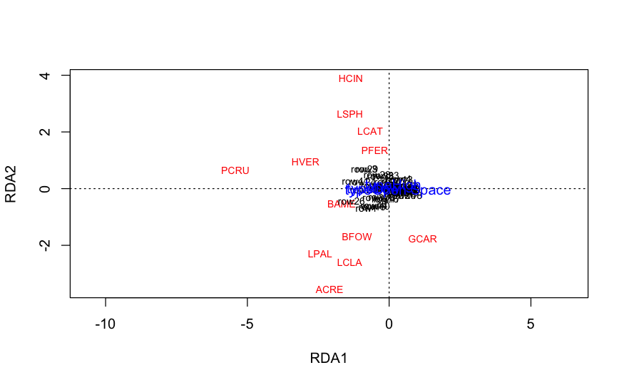

```r
ordiplot(hutto1.rda,scaling=1,type="text")
```

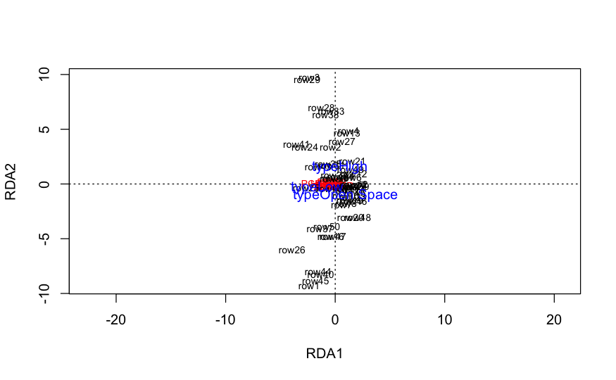

```r
ordiplot(hutto1.rda,scaling=2,type="text")
```

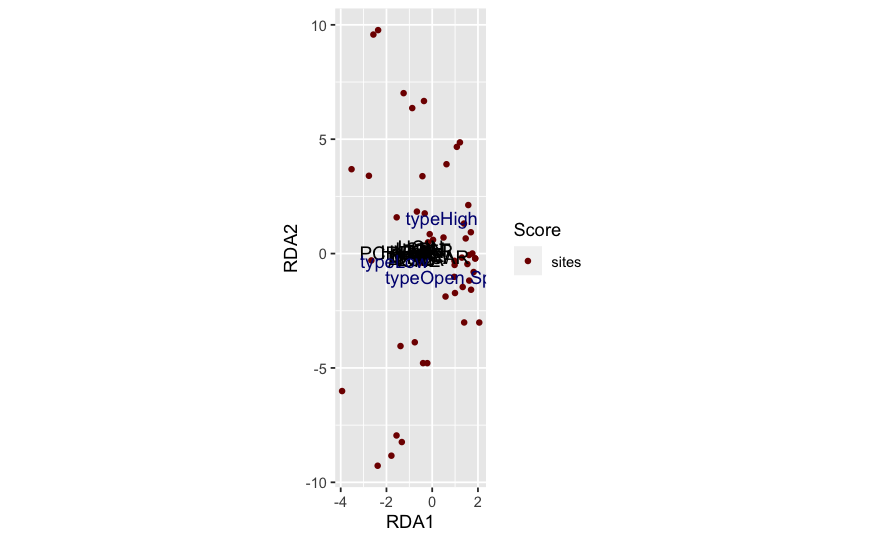

```r
autoplot(hutto1.rda, data=huttoamph, colour= "type", scale=1,
         loadings = TRUE, loadings.colour = 'black',
         loadings.label = TRUE, loadings.label.size = 3,
         loadings.label.colour="black", loadings.label.hjust=-0.25
         )+
scale_color_uchicago()
```

**Does the kind of urbanization have a strong effect on the frog assemblage?** > Not really. RDA1 & 2 account for very little variation.

**Are there easily distinguishable frog groupings?** >Again, not strong patterns. Some loadings, but PCs don’t account for too much - PC1 and 2 are the best, but only account for 40% or so.

*Hint: The visualizations might be a bit hard to see; if that’s the case, try a simple PCA on the frogs (i.e. omitting urbanization type)

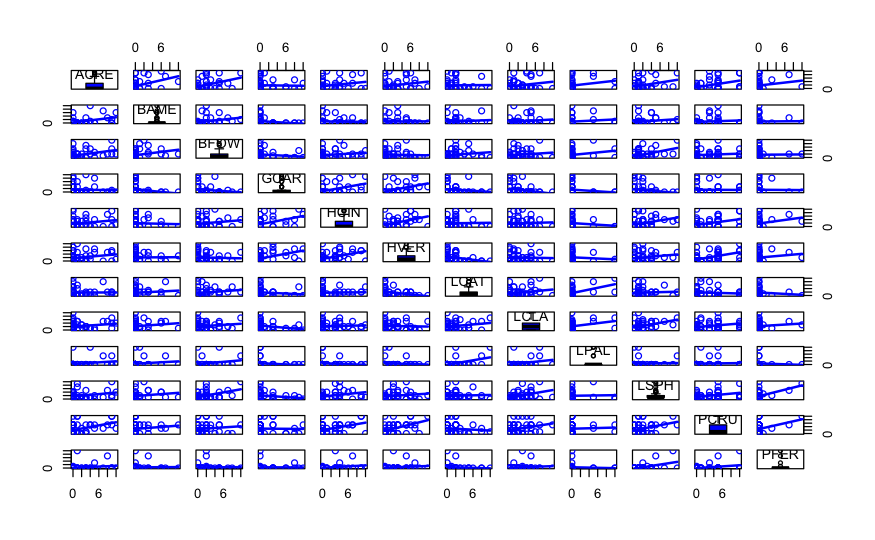

```r
scatterplotMatrix(~ACRE+BAME+BFOW+GCAR+HCIN+HVER+LCAT+LCLA+LPAL+LSPH+PCRU+PFER,data=huttoamph,smooth = FALSE, diagonal=list(method='boxplot'))
```

```r
#do pca on correlation matrix with princomp

huttoamph1.pca <- princomp(~ACRE+BAME+BFOW+GCAR+HCIN+HVER+LCAT+LCLA+LPAL+LSPH+PCRU+PFER, cor=T, data=huttoamph)
summary(huttoamph1.pca)
```

```
Importance of components:
                             Comp.1       Comp.2       Comp.3        Comp.4        Comp.5        Comp.6        Comp.7        Comp.8       Comp.9       Comp.10       Comp.11
Standard deviation     1.7214553754 1.5367637803 1.1538635041 1.07535238116 0.98437712305 0.85345487453 0.81647024380 0.74100951985 0.6923373377 0.56828795921 0.54056741754
Proportion of Variance 0.2469507175 0.1968035764 0.1109500822 0.09636522864 0.08074986003 0.06069876857 0.05555197158 0.04575792571 0.0399442491 0.02691260038 0.02435109441
Cumulative Proportion  0.2469507175 0.4437542938 0.5547043760 0.65106960463 0.73181946466 0.79251823323 0.84807020482 0.89382813053 0.9337723796 0.96068498001 0.98503607442
                             Comp.12
Standard deviation     0.42375359227
Proportion of Variance 0.01496392558
Cumulative Proportion  1.00000000000
```

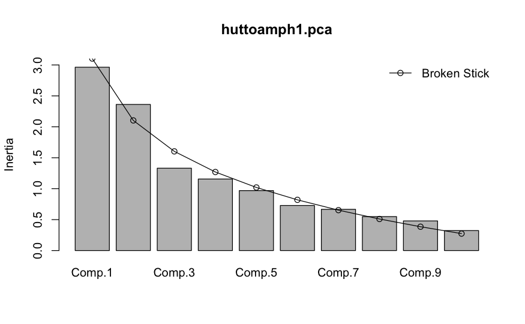

```r
screeplot(huttoamph1.pca,bstick=TRUE, bst.col="black",xlab = "Component", ylab = "Inertia",)
```

```r
loadings(huttoamph1.pca)
```

```
Loadings:
     Comp.1 Comp.2 Comp.3 Comp.4 Comp.5 Comp.6 Comp.7 Comp.8 Comp.9 Comp.10 Comp.11 Comp.12
ACRE  0.403         0.162  0.392         0.143  0.194         0.640  0.419
BAME  0.230  0.221         0.562         0.279 -0.602        -0.274 -0.224
BFOW  0.313  0.231  0.144  0.201 -0.552 -0.277  0.350        -0.137 -0.257  -0.313  -0.316
GCAR        -0.447  0.454 -0.107 -0.138  0.132 -0.147  0.433  0.121 -0.154  -0.442   0.320
HCIN  0.305 -0.341  0.261 -0.232 -0.286 -0.115 -0.225 -0.247  0.180 -0.252   0.594  -0.119
HVER  0.254 -0.447  0.178         0.268                      -0.493  0.437          -0.421
LCAT         0.369  0.402 -0.404         0.225 -0.262 -0.446         0.332  -0.299
LCLA  0.289  0.256 -0.116 -0.320  0.340 -0.421 -0.355  0.393  0.260         -0.132  -0.264
LPAL  0.128  0.358  0.413 -0.211  0.299  0.246  0.418  0.299 -0.210 -0.215   0.348   0.125
LSPH  0.436        -0.308 -0.202 -0.301 -0.122         0.161 -0.290  0.335           0.575
PCRU  0.402 -0.173                0.446         0.159 -0.506        -0.364  -0.311   0.286
PFER  0.273 -0.125 -0.444 -0.262 -0.106  0.691         0.105        -0.149  -0.114  -0.313

               Comp.1 Comp.2 Comp.3 Comp.4 Comp.5 Comp.6 Comp.7 Comp.8 Comp.9 Comp.10 Comp.11 Comp.12
SS loadings     1.000  1.000  1.000  1.000  1.000  1.000  1.000  1.000  1.000   1.000   1.000   1.000
Proportion Var  0.083  0.083  0.083  0.083  0.083  0.083  0.083  0.083  0.083   0.083   0.083   0.083
Cumulative Var  0.083  0.167  0.250  0.333  0.417  0.500  0.583  0.667  0.750   0.833   0.917   1.000
```

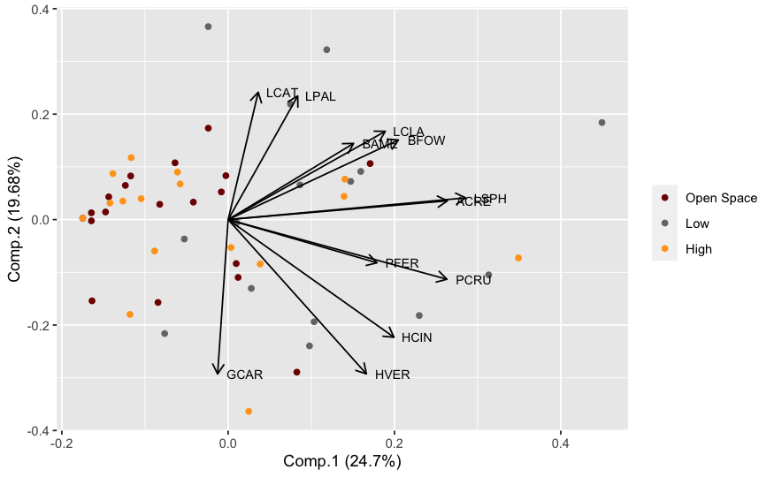

```r
autoplot(huttoamph1.pca, data=huttoamph, colour= "type", scale=1,
         loadings = TRUE, loadings.colour = 'black',
         loadings.label = TRUE, loadings.label.size = 3,
         loadings.label.colour="black", loadings.label.hjust=-0.25
         )+
scale_color_uchicago()+
  theme(
    legend.title = element_blank()
  )
```

### Try using the environmental variables to constrain the ordination, rather than the habitat categories. Does a clearer pattern emerge?

**Think about the distributions of the habitat variables:**

**Are there correlations between them?**

**Do any variables need transformation before PCA**

```r
#Get summary stats
stat_funs <- lst(min, median, mean, max, sd)
huttoenv %>%
    dplyr::summarise(across(ph:wetlandnear, stat_funs,
        na.rm = TRUE, .names = "{.col}__{.fn}")) %>%
    pivot_longer(everything()) %>%
    separate(name, c('v', 'f'), sep = '__') %>%
    pivot_wider(names_from = v, values_from = value)
```

| f | ph | cond | wdepth | omdepth | cancov | area | rivernear | wetlandnear |
| --- | --- | --- | --- | --- | --- | --- | --- | --- |
| min | 5.9900000000 | 15.73000000 | 0.1200000000 | 0.480000000 | 0.00000000 | 0.0000000000 | 0.0000000 | 0.0000000 |
| median | 6.8400000000 | 49.27000000 | 1.2000000000 | 4.450000000 | 33.00000000 | 0.1800000000 | 22.0400000 | 61.0100000 |
| mean | 6.8629411765 | 64.07921569 | 0.9794117647 | 5.003529412 | 33.35294118 | 0.5017647059 | 130.4509804 | 128.1031373 |
| max | 8.1300000000 | 158.47000000 | 1.2000000000 | 15.660000000 | 88.00000000 | 4.1800000000 | 802.8000000 | 731.7600000 |
| sd | 0.4719249691 | 36.86961198 | 0.3657507991 | 3.224096043 | 25.44627559 | 0.9337659362 | 180.6320936 | 162.0757900 |

```r
#Look at correlations
cor(huttoenv[,c('ph','cond','wdepth','omdepth','cancov','area','rivernear','wetlandnear')])
```

```
                        ph           cond         wdepth        omdepth         cancov           area       rivernear     wetlandnear
ph           1.00000000000  0.07503859643  0.29690443684 -0.15271231625 -0.01357835385  0.23704202199 -0.028117481376 -0.029089827074
cond         0.07503859643  1.00000000000 -0.19119030441  0.07520922708 -0.10720201230  0.03262864131  0.144953920865 -0.346369336675
wdepth       0.29690443684 -0.19119030441  1.00000000000 -0.17011635924  0.13177311062  0.26349137220 -0.047577204440 -0.010413375327
omdepth     -0.15271231625  0.07520922708 -0.17011635924  1.00000000000  0.32700542534 -0.09462731151  0.052500672274 -0.041884613338
cancov      -0.01357835385 -0.10720201230  0.13177311062  0.32700542534  1.00000000000  0.12097053976 -0.068399354511  0.101022628148
area         0.23704202199  0.03262864131  0.26349137220 -0.09462731151  0.12097053976  1.00000000000 -0.241691586832 -0.202471119254
rivernear   -0.02811748138  0.14495392086 -0.04757720444  0.05250067227 -0.06839935451 -0.24169158683  1.000000000000 -0.009786465279
wetlandnear -0.02908982707 -0.34636933668 -0.01041337533 -0.04188461334  0.10102262815 -0.20247111925 -0.009786465279  1.000000000000
```

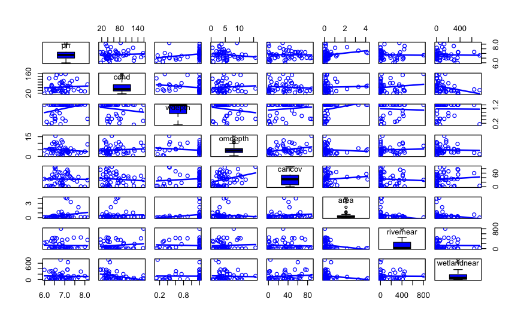

```r
#Do scatterplot matrices
scatterplotMatrix(~ph+cond+wdepth+omdepth+cancov+area+rivernear+wetlandnear,data=huttoenv,smooth = FALSE, diagonal=list(method='boxplot'))
```

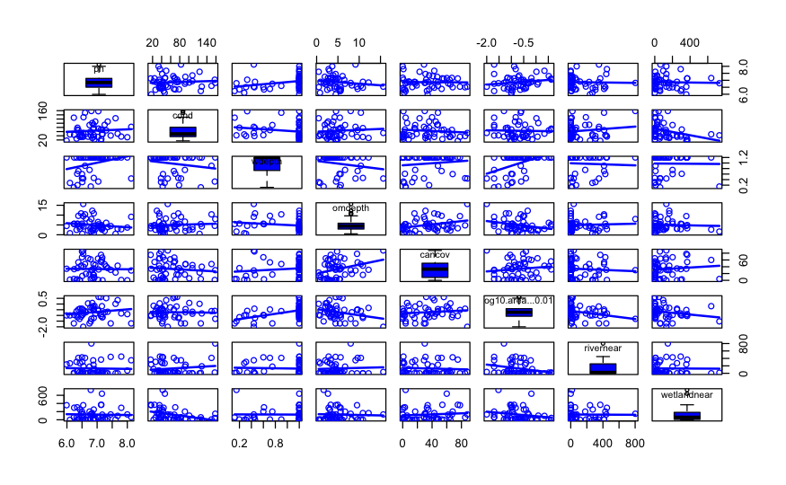

```r
scatterplotMatrix(~ph+cond+wdepth+omdepth+cancov+log10(area+0.01)+rivernear+wetlandnear,data=huttoenv, smooth = FALSE, diagonal=list(method='boxplot'))
```

> Correlation and scatterplot matrices - correlations low Area strongly skewed with outliers - transform log10 area + 0.01 (there is one wetland with 0.00ha)

```r
huttoenv$larea <- log10(huttoenv$area+0.01)
```

**Should you standardise the data?** >Probably yes, given different measurement scales for the environmental variables

```r
huttoenv1 <- subset(huttoenv,site != 17)
head(huttoenv1,10)
```

| site | type | group | ph | cond | wdepth | omdepth | cancov | area | rivernear | wetlandnear | larea |
| --- | --- | --- | --- | --- | --- | --- | --- | --- | --- | --- | --- |
| 1 | Low | 1 | 6.54 | 35.17 | 1.20 | 9.49 | 78 | 0.29 | 0.00 | 357.55 | -0.52287874528 |
| 2 | High | 2 | 6.32 | 26.53 | 1.20 | 2.50 | 1 | 0.22 | 307.11 | 55.72 | -0.63827216398 |
| 3 | Low | 1 | 7.04 | 157.43 | 0.33 | 4.55 | 1 | 0.24 | 21.12 | 43.91 | -0.60205999133 |
| 4 | High | 2 | 7.80 | 36.23 | 1.20 | 2.82 | 1 | 0.14 | 449.35 | 293.66 | -0.82390874094 |
| 5 | Open Space | 3 | 7.18 | 47.73 | 1.20 | 3.28 | 0 | 0.06 | 21.23 | 7.97 | -1.15490195999 |
| 6 | Open Space | 3 | 6.42 | 35.93 | 1.20 | 4.17 | 0 | 0.04 | 26.04 | 7.97 | -1.30102999566 |
| 7 | Open Space | 3 | 6.84 | 101.07 | 1.20 | 2.42 | 6 | 1.23 | 0.00 | 101.83 | 0.09342168516 |
| 8 | Open Space | 3 | 6.63 | 49.27 | 1.20 | 8.27 | 19 | 0.18 | 0.00 | 8.90 | -0.72124639905 |
| 9 | Open Space | 3 | 6.89 | 43.33 | 1.20 | 0.92 | 9 | 0.27 | 0.00 | 8.90 | -0.55284196866 |
| 10 | Open Space | 3 | 6.24 | 44.43 | 1.20 | 5.62 | 33 | 0.10 | 1.58 | 295.02 | -0.95860731484 |

```r
huttoenv1 <- huttoenv1 %>%
  dplyr::mutate(across(ph:larea, scale))
head(huttoenv1, 10)
```

| site | type | group | ph | cond | wdepth | omdepth | cancov | area | rivernear | wetlandnear | larea |
| --- | --- | --- | --- | --- | --- | --- | --- | --- | --- | --- | --- |
| 1 | Low | 1 | -0.66326217828 | -0.7648992362 | 0.6112622679 | 1.3777258696 | 1.73179855122 | -0.2140056633 | -0.7331425605 | 1.3946284057 | 0.35068344381 |
| 2 | High | 2 | -1.13702087706 | -1.0033592820 | 0.6112622679 | -0.8129710887 | -1.26884250288 | -0.2884609139 | 0.9589919034 | -0.4596819610 | 0.15794610895 |
| 3 | Low | 1 | 0.41346213711 | 2.6094208098 | -1.7522851680 | -0.1704920093 | -1.26884250288 | -0.2671879852 | -0.6167742239 | -0.5322373910 | 0.21842995392 |
| 4 | High | 2 | 2.05008309651 | -0.7356437213 | 0.6112622679 | -0.7126816714 | -1.26884250288 | -0.3735526289 | 1.7427150194 | 1.0021164310 | -0.15211576025 |
| 5 | Open Space | 3 | 0.71494494542 | -0.4182489845 | 0.6112622679 | -0.5685156341 | -1.30781186722 | -0.4586443440 | -0.6161681388 | -0.7530368960 | -0.70496142176 |
| 6 | Open Space | 3 | -0.92167601398 | -0.7439235840 | 0.6112622679 | -0.2895856923 | -1.30781186722 | -0.4799172727 | -0.5896656909 | -0.7530368960 | -0.94903364409 |
| 7 | Open Space | 3 | -0.01722758905 | 1.0539106037 | 0.6112622679 | -0.8380434430 | -1.07399568118 | 0.7858219882 | -0.7331425605 | -0.1764024626 | 1.38006712768 |
| 8 | Open Space | 3 | -0.46945180151 | -0.3757456893 | 0.6112622679 | 0.9953724663 | -0.56739394478 | -0.3310067714 | -0.7331425605 | -0.7473233862 | 0.01935733059 |
| 9 | Open Space | 3 | 0.09044484249 | -0.5396869708 | 0.6112622679 | -1.3081500864 | -0.95708758816 | -0.2352785920 | -0.7331425605 | -0.7473233862 | 0.30063698638 |
| 10 | Open Space | 3 | -1.30929676752 | -0.5093274742 | 0.6112622679 | 0.1648507296 | -0.02182284403 | -0.4160984864 | -0.7244369748 | 1.0104716710 | -0.37709777773 |

#### Now do the RDA, once you’re happy with the data

*Important hint: One pond has no anuran data, but has environmental data. You’ll need to exclude pond 17 from the huttoenv data at some stage*

```r
#huttoamph$type <- factor(huttoamph$type,levels=c("Open Space","Low","High"))  #Makes open space the reference condition. Not critical, but helps with interpretation
huttoenv2 <- huttoenv1[,-(1:3)]
hutto2.rda <- rda(huttoamph1~ ph + cond + wdepth + omdepth + cancov + larea + rivernear + wetlandnear, scale=FALSE, data=huttoenv1)
summary(hutto2.rda)
```

```
Call:
rda(formula = huttoamph1 ~ ph + cond + wdepth + omdepth + cancov +      larea + rivernear + wetlandnear, data = huttoenv1, scale = FALSE)

Partitioning of variance:
               Inertia Proportion
Total         74.26571  1.0000000
Constrained   23.70297  0.3191644
Unconstrained 50.56274  0.6808356

Eigenvalues, and their contribution to the variance

Importance of components:
                            RDA1       RDA2       RDA3       RDA4        RDA5        RDA6        RDA7         RDA8        PC1        PC2       PC3        PC4        PC5        PC6
Eigenvalue            10.9677221 5.60957631 3.69018014 2.14224278 0.640189167 0.384548739 0.206202876 0.0623096457 15.2776542 7.07944308 6.2331141 4.68076345 4.12409640 3.18667434
Proportion Explained   0.1476822 0.07553386 0.04968888 0.02884565 0.008620252 0.005178012 0.002776555 0.0008390096  0.2057161 0.09532586 0.0839299 0.06302725 0.05553163 0.04290909
Cumulative Proportion  0.1476822 0.22321604 0.27290492 0.30175057 0.310370818 0.315548830 0.318325385 0.3191643948  0.5248805 0.62020637 0.7041363 0.76716352 0.82269515 0.86560424
                             PC7        PC8        PC9       PC10       PC11       PC12
Eigenvalue            2.67237518 2.23028297 1.83432149 1.61173738 0.88716600 0.74511400
Proportion Explained  0.03598397 0.03003113 0.02469944 0.02170231 0.01194584 0.01003308
Cumulative Proportion 0.90158821 0.93161934 0.95631878 0.97802108 0.98996692 1.00000000

Accumulated constrained eigenvalues
Importance of components:
                            RDA1      RDA2      RDA3       RDA4       RDA5       RDA6        RDA7        RDA8
Eigenvalue            10.9677221 5.6095763 3.6901801 2.14224278 0.64018917 0.38454874 0.206202876 0.062309646
Proportion Explained   0.4627151 0.2366613 0.1556843 0.09037866 0.02700881 0.01622365 0.008699452 0.002628769
Cumulative Proportion  0.4627151 0.6993764 0.8550607 0.94543931 0.97244813 0.98867178 0.997371231 1.000000000

Scaling 2 for species and site scores
* Species are scaled proportional to eigenvalues
* Sites are unscaled: weighted dispersion equal on all dimensions
* General scaling constant of scores:  7.766871333


Species scores

            RDA1         RDA2        RDA3        RDA4        RDA5        RDA6
ACRE -1.49111649 -0.543175898  0.05450991  0.67569315 -0.05816315  0.12058124
BAME -0.80289534 -0.355923137  0.27602488  0.32306213  0.24874224 -0.28106492
BFOW -1.02646424  0.034315411 -0.44945948 -0.42200534 -0.21433533  0.07441036
```

[output cut: 117 more lines]

```
row49  1.34236478 -0.54624742 -1.073067792  0.001872434  1.350868908 -3.21320102
row50  0.23282494  0.96786438  1.754569072  1.329091446 -1.182765974  1.30513734


Biplot scores for constraining variables

                   RDA1         RDA2        RDA3        RDA4        RDA5        RDA6
ph          -0.04018903  0.137699044 -0.74025418 -0.12292388 -0.05296804 -0.43698143
cond         0.06880470 -0.061097368 -0.04416525 -0.54434112  0.69565339  0.35177398
wdepth      -0.56281980  0.613567688 -0.32744765  0.06348253 -0.21009105  0.17342968
omdepth     -0.38910876 -0.001652306  0.42431685  0.36521298  0.54102385 -0.30829779
cancov      -0.54007727  0.141703537  0.46590297 -0.38341855 -0.32386202 -0.30334776
larea       -0.69768618 -0.370056723 -0.37034124 -0.15575870 -0.28698731  0.27381256
rivernear    0.29175898  0.042161522  0.34969813 -0.08011466  0.14491584 -0.05440847
wetlandnear  0.23313920  0.142200854  0.12524906  0.39777626 -0.56185583  0.29601199
```

```r
RsquareAdj(hutto2.rda)
```

```
$r.squared
[1] 0.3191643948

$adj.r.squared
[1] 0.1863184231
```

```r
coef(hutto2.rda)
```

```
                        RDA1            RDA2            RDA3           RDA4            RDA5           RDA6             RDA7           RDA8
ph           0.0122442583308 -0.007849171404 -0.095276551142 -0.01116114378 -0.002158984681 -0.08831197396  0.0597190463030 -0.04245657570
cond         0.0007442991191  0.023681190390 -0.012065012565 -0.07863867178  0.069462823667  0.09575845966  0.0276925923182 -0.06227608362
wdepth      -0.0505595498209  0.149991564243 -0.014970885383  0.01837596345  0.018206157836  0.05104502088 -0.0027161111779  0.03755516757
omdepth     -0.0724966022225 -0.025000927127  0.019277747132  0.10615598256  0.080448552827 -0.02342612777  0.0358783548408 -0.03375815826
cancov      -0.0348980638674  0.028067030099  0.068045579399 -0.10669196102 -0.059838630268 -0.04968279307  0.0000106835282 -0.03776935974
larea       -0.0839838554353 -0.137100681908 -0.025005865745  0.01720533827 -0.025659288224  0.04876402768  0.0519125780324  0.01809405896
rivernear    0.0182497357745 -0.024508347794  0.049169026660 -0.00304452550 -0.005474714960 -0.01158765282  0.1147002540228  0.07894564821
wetlandnear  0.0165844547821 -0.002569457508  0.004436856501  0.05096107835 -0.051207307876  0.08598414287  0.0672825523169 -0.08676234616
```

```r
anova.cca(hutto2.rda, permutations=1000)
```

```
Permutation test for rda under reduced model
Permutation: free
Number of permutations: 1000

Model: rda(formula = huttoamph1 ~ ph + cond + wdepth + omdepth + cancov + larea + rivernear + wetlandnear, data = huttoenv1, scale = FALSE)
         Df  Variance       F   Pr(>F)
Model     8 23.702972 2.40251 0.000999 ***
Residual 41 50.562743
---
Signif. codes:  0 ‘***’ 0.001 ‘**’ 0.01 ‘*’ 0.05 ‘.’ 0.1 ‘ ’ 1
```

```r
anova.cca(hutto2.rda, permutations=1000, by="margin")
```

```
Permutation test for rda under reduced model
Marginal effects of terms
Permutation: free
Number of permutations: 1000

Model: rda(formula = huttoamph1 ~ ph + cond + wdepth + omdepth + cancov + larea + rivernear + wetlandnear, data = huttoenv1, scale = FALSE)
            Df  Variance       F   Pr(>F)
ph           1  1.753478 1.42185 0.187812
cond         1  0.938147 0.76072 0.634366
wdepth       1  5.241569 4.25025 0.002997 **
omdepth      1  3.387323 2.74669 0.010989 *
cancov       1  2.454581 1.99036 0.055944 .
larea        1  5.715930 4.63490 0.001998 **
rivernear    1  0.835123 0.67718 0.714286
wetlandnear  1  0.585300 0.47460 0.873127
Residual    41 50.562743
---
Signif. codes:  0 ‘***’ 0.001 ‘**’ 0.01 ‘*’ 0.05 ‘.’ 0.1 ‘ ’ 1
```

```r
anova.cca(hutto2.rda, permutations=1000, by="axis")
```

```
Permutation test for rda under reduced model
Forward tests for axes
Permutation: free
Number of permutations: 1000

Model: rda(formula = huttoamph1 ~ ph + cond + wdepth + omdepth + cancov + larea + rivernear + wetlandnear, data = huttoenv1, scale = FALSE)
         Df  Variance       F   Pr(>F)
RDA1      1 10.967722 8.89344 0.000999 ***
RDA2      1  5.609576 4.54866 0.096903 .
RDA3      1  3.690180 2.99227 0.282717
RDA4      1  2.142243 1.73709 0.789211
RDA5      1  0.640189 0.51911 1.000000
RDA6      1  0.384549 0.31182 1.000000
RDA7      1  0.206203 0.16720 1.000000
RDA8      1  0.062310 0.05053 1.000000
Residual 41 50.562743
---
Signif. codes:  0 ‘***’ 0.001 ‘**’ 0.01 ‘*’ 0.05 ‘.’ 0.1 ‘ ’ 1
```

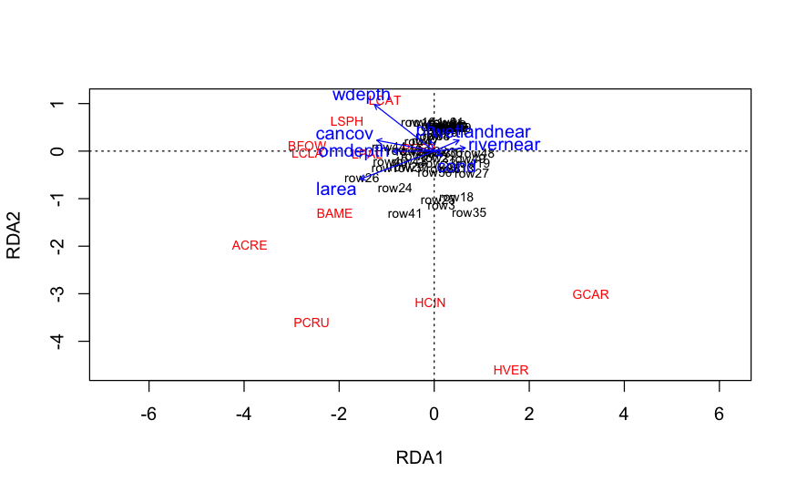

```r
ordiplot(hutto2.rda,scaling=1,type="text")
```

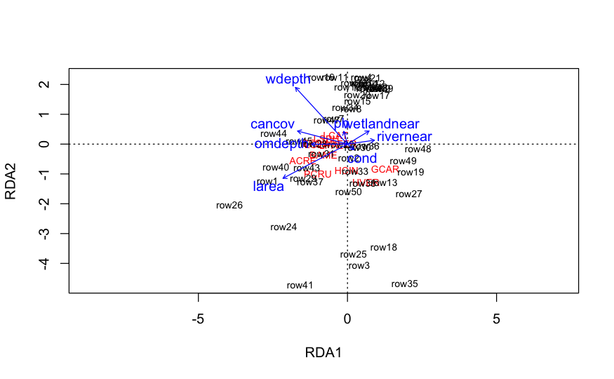

```r
ordiplot(hutto2.rda,scaling=2,type="text")
```

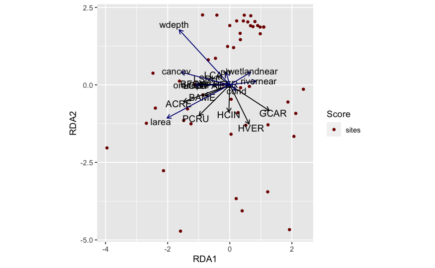

```r
autoplot(hutto2.rda, data=huttoenv2, colour= "type", scale=1,
         loadings = TRUE, loadings.colour = 'black',
         loadings.label = TRUE, loadings.label.size = 3,
         loadings.label.colour="black", loadings.label.hjust=-0.25
         )+
scale_color_uchicago()
```

> Not specatcular, but the habitat variables do markedly bettern than urbanization type, particularly associated with first axis. The environmental variables that have most influence seem to be pond area, canopy cover, and the depth of both pond and organic matter.

## C. LDA

Militão et al. (2014) were interested in how easy it was to distinguish between two closely-related shearwaters, the Yelkouan and the Balearctic. Genetic analyses suggested that these birds diverged relatively recently, and can be hard to identify visually, and they overlap in parts of their ranges in the western Mediterranean. Both are caught as by-catch in commercial longline fisheries, but they differ in conservation status, with the Balearctic being critically endangered and the Yelkouan vulnerable. This difference in conservation status makes it important to identify by-catch, particularly as they may differ in vulnerability to fishing.

Militao and colleagues used several approaches, from biometric measurements to Stable Isotope Analysis to plumage colour to bill morphology, to identify a simple method for identifying bycatch, without having to resort to costly and time-consuming genetic analysis. They applied these approaches to a sample of birds of known species identity.

We’ll focus on the biometric data, because this information can be recorded easily while on a fishing vessel, and requires little training. The question of interest is:

## Can we use biometric measurements to reliably classify a bird to species?

**Their data** are in supplement S1 of the paper. They’re an Excel file, and you’ll need to skip the first 6 rows to get to the variable names in row 7. If you’ve copied the file into your downloads folder, the next line of code will read in this data frame:

militao <- read_excel(“~/Downloads/pone.0115650.s003.xlsx”, skip = 6)

We’ve used a tidied up version (militao.csv)

The variables of relevance are:

- sex
- spp: species
- sppsex: a composite variable combining sex and species to a single variable with four values
- year: when bird was collected (not used)
- bdb: bill depth at base
- bdn: bill depth at nostril
- bl: bill length
- mhl: maximum head length
- tl: tarsus length
- wl: wing length

```r
militao <- read_csv("data/militao.csv")
head(militao,10)
```

| dataset | birdid | sex | spp | sppsex | year | bdb | bdn | bl | mhl | tl | wl |
| --- | --- | --- | --- | --- | --- | --- | --- | --- | --- | --- | --- |
| a | 1 | m | ys | ysm | 2002 | 10.48 | 7.55 | 36.37 | 85.16 | 45.98 | 237.0 |
| a | 20 | f | bs | bsf | 2002 | 11.54 | 8.71 | 38.21 | 89.42 | 51.04 | 251.0 |
| a | 21 | f | bs | bsf | 2002 | 11.69 | 8.74 | 38.02 | 88.60 | 48.20 | 253.0 |
| a | 23 | f | bs | bsf | 2002 | 11.45 | 8.40 | 38.90 | 90.02 | 50.88 | 263.0 |
| a | 138 | f | bs | bsf | 2004 | 11.29 | 8.02 | 38.22 | 87.82 | 49.24 | 250.0 |
| a | 140 | m | bs | bsm | 2004 | 12.70 | 9.22 | 38.99 | 91.75 | 51.66 | 261.0 |
| a | 141 | f | bs | bsf | 2004 | 10.78 | 7.95 | 37.70 | 88.43 | 49.89 | 253.0 |
| a | 142 | m | u | um | 2004 | 11.42 | 8.59 | 39.03 | 91.46 | 49.09 | 241.5 |
| a | 143 | f | bs | bsf | 2004 | 11.96 | 9.10 | 35.68 | 86.50 | 47.77 | 257.0 |
| a | 214 | f | ys | ysf | 2005 | 10.29 | 6.77 | 35.16 | 82.05 | 46.59 | 225.0 |

Analysis in the paper uses data from this file, but excludes birds that could not be assigned to species (labelled unknown), and for the LDA, uses a subset of the data (“a”).

Militao et al. also standardised their biometric variables - “translation” - to remove sexual differences - subtracted sex-species mean for each variable.

```r
militao1 <- filter(militao, dataset=='a' & spp %in% c('ys','bs'))

#Centre the morphological variables
militao1 <- militao1 %>%
  dplyr::group_by(sppsex) %>%
  mutate(
    bdbm = mean(bdb),
    bdnm = mean(bdn),
    blm = mean(bl),
    mhlm = mean(mhl),
    tlm = mean(tl),
    wlm = mean(wl)
    ) %>%
  ungroup() %>%
  mutate(
    bdbc = bdb - bdbm,
    bdnc = bdn - bdnm,
    blc = bl - blm,
    mhlc = mhl - mhlm,
    tlc = tl - tlm,
    wlc = wl - wlm
  )

head(militao1)
```

[output not shown]

### Use discriminant analysis (LDA) to decide whether these morphological measurements are enough to distinguish these shearwater species

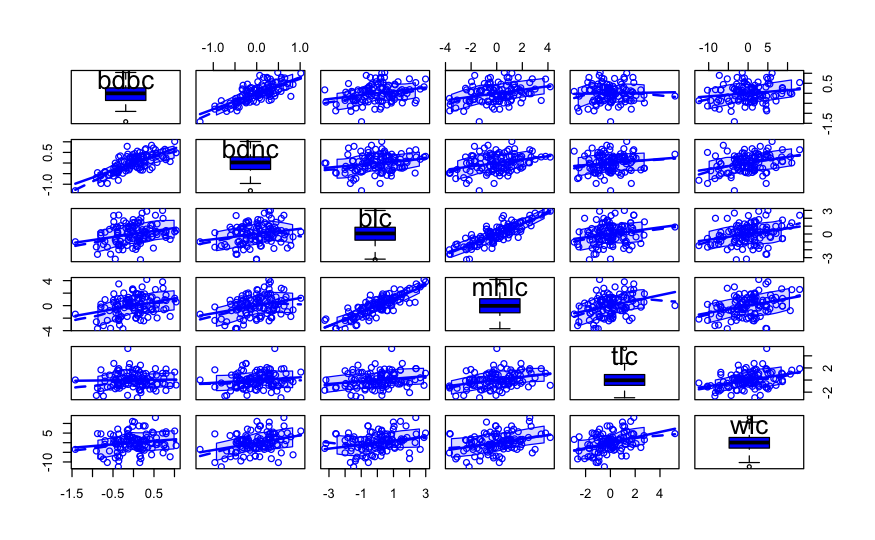

```r
# check linearity and distributions
scatterplotMatrix(~bdbc+bdnc+blc+mhlc+tlc+wlc,data=militao1,diagonal=list(method='boxplot'))
```

```r
# check homog variances and covariances
militao1.dist <- dist(militao1[,-(1:6)])
militao1.disp <- betadisper(militao1.dist,militao1$spp)
permutest(militao1.disp)
```

```
Permutation test for homogeneity of multivariate dispersions
Permutation: free
Number of permutations: 999

Response: Distances
           Df     Sum Sq    Mean Sq       F N.Perm Pr(>F)
Groups      1    4.48457  4.4845656 0.32111    999  0.564
Residuals 111 1550.21926 13.9659393
```

```r
anova(militao1.disp)
```

```
Analysis of Variance Table

Response: Distances
           Df     Sum Sq    Mean Sq F value  Pr(>F)
Groups      1    4.48457  4.4845656 0.32111 0.57209
Residuals 111 1550.21926 13.9659393
```

```r
# LDA with jackknife CV
militaojac.lda <- lda(spp~bdbc+bdnc+blc+mhlc+tlc+wlc, data=militao1, CV=TRUE)
print(militaojac.lda)
```

```
$class
  [1] bs bs bs bs bs bs bs bs bs bs bs bs bs bs bs bs bs bs bs bs bs bs bs bs bs bs bs bs bs bs bs bs bs bs bs bs bs bs bs bs bs bs bs bs bs bs bs bs bs bs bs bs bs bs bs bs bs bs bs
 [60] bs bs bs bs bs bs bs bs ys bs bs ys bs bs bs bs bs bs bs bs bs bs ys bs bs bs bs bs bs bs bs ys bs bs bs bs bs bs bs bs bs bs bs bs bs bs bs bs bs bs bs bs bs bs
Levels: bs ys

$posterior
              bs           ys
1   0.5905166894 0.4094833106
2   0.5286303140 0.4713696860
3   0.5382534332 0.4617465668
4   0.5172391708 0.4827608292
5   0.5418792803 0.4581207197
6   0.5242543251 0.4757456749
7   0.5316640282 0.4683359718
8   0.5044314850 0.4955685150
```

[output cut: 141 more lines]

```r
table(militao1$spp,militaojac.lda$class)
```

```
     bs ys
  bs 58  4
  ys 51  0
```

```r
# use Borcard code to get props correct
militaojac.class <- militaojac.lda$class
militaojac.table <- table(militao1$spp, militaojac.class)
diag(prop.table(militaojac.table,1))
```

```
         bs          ys
0.935483871 0.000000000
```

```r
# use DAAG confusion to get overall accuracy
confusion(militaojac.lda$class,militao1$spp)
```

```
Overall accuracy = 0.513

Confusion matrix
      Predicted (cv)
Actual    bs    ys
    bs 0.532 0.468
    ys 1.000 0.000
```

```r
# LDA
militao1.lda <- lda(spp~bdbc+bdnc+blc+mhlc+tlc+wlc, data=militao1)
print(militao1.lda)
```

```
Call:
lda(spp ~ bdbc + bdnc + blc + mhlc + tlc + wlc, data = militao1)

Prior probabilities of groups:
          bs           ys
0.5486725664 0.4513274336

Group means:
               bdbc             bdnc             blc             mhlc              tlc              wlc
bs  2.578582509e-16  1.217663962e-16 6.303201688e-16 -2.435327925e-15 -6.159947104e-16  1.002782087e-15
ys -3.091209206e-16 -6.966105253e-17 3.853126968e-16 -2.069014894e-15  2.630112903e-15 -3.169577890e-15

Coefficients of linear discriminants:
               LD1
bdbc -1.1994372907
bdnc  0.7620839958
blc  -0.1135323710
mhlc  0.1041417991
tlc   0.7052457204
wlc  -0.1301675073
```

```r
# get eigenvalues (prop explained)
militao1.lda$svd
```

```
[1] 1.815758539e-14
```

```r
propexp <- militao1.lda$svd^2/sum(militao1.lda$svd^2)
propexp
```

```
[1] 1
```

```r
militao1.pred <- predict(militao1.lda)
table(militao1$spp,militao1.pred$class)
```

```
     bs ys
  bs 62  0
  ys 51  0
```

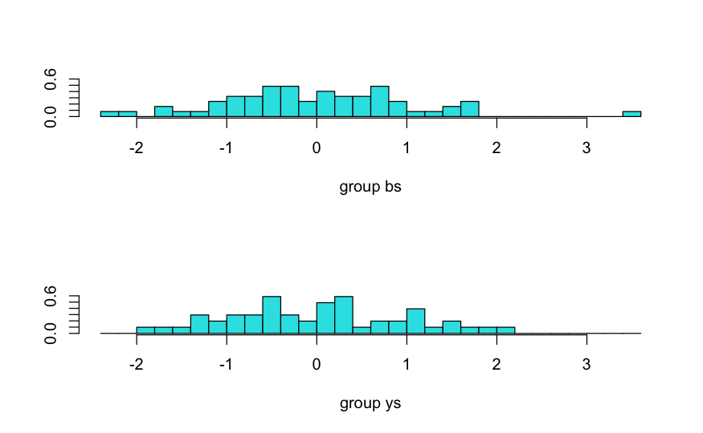

```r
plot(militao1.lda, dimen=2)
```

### Sensitivity

The paper’s authors chose to adjust for bird sex by subtracting the mean value for that bird species/sex from each measurement, before running their LDA.

**Did that decision improve the discriminatory capacity, i.e. what would have happened if raw data were used?** >Students should run LDA again with uncentred variables

```r
militao2.lda <- lda(spp~bdb+bdn+bl+mhl+tl+wl, data=militao1)
print(militao2.lda)
```

```
Call:
lda(spp ~ bdb + bdn + bl + mhl + tl + wl, data = militao1)

Prior probabilities of groups:
          bs           ys
0.5486725664 0.4513274336

Group means:
           bdb         bdn          bl         mhl          tl          wl
bs 11.95064516 8.761612903 38.48661290 89.58419355 49.92419355 252.0967742
ys 10.91607843 7.816666667 37.11784314 85.45215686 47.58529412 238.8333333

Coefficients of linear discriminants:
               LD1
bdb -0.75366849743
bdn  0.43492788573
bl   0.48622104812
mhl -0.28164296664
tl  -0.02675217801
wl  -0.16300365917
```

```r
militao2.pred <- predict(militao2.lda)
table(militao1$spp,militao2.pred$class)
```

```
     bs ys
  bs 57  5
  ys  5 46
```

```r
confusion(militao2.pred$class,militao1$spp)
```

```
Overall accuracy = 0.912

Confusion matrix
      Predicted (cv)
Actual    bs    ys
    bs 0.919 0.081
    ys 0.098 0.902
```

**Can you think of another way of adjusting for sex of bird?** >Could use the variable sppsex, which combines species and sex. We’d then be interested in four quadrants of the 4x4 classification table. We’re less interested in whether we can classify a bird’s sex from morphometrics, but it’s species IDs of interest. We’re looking to see if the small number of misclassified birds disappears.

```r
militao3.lda <- lda(sppsex~bdb+bdn+bl+mhl+tl+wl, data=militao1)
print(militao3.lda)
```

```
Call:
lda(sppsex ~ bdb + bdn + bl + mhl + tl + wl, data = militao1)

Prior probabilities of groups:
         bsf          bsm          ysf          ysm
0.2831858407 0.2654867257 0.2920353982 0.1592920354

Group means:
            bdb         bdn          bl         mhl          tl          wl
bsf 11.47437500 8.394062500 37.46875000 87.46812500 49.24343750 251.9218750
bsm 12.45866667 9.153666667 39.57233333 91.84133333 50.65033333 252.2833333
ysf 10.65969697 7.585151515 36.63242424 84.20484848 47.07393939 237.4848485
ysm 11.38611111 8.241111111 38.00777778 87.73888889 48.52277778 241.3055556

Coefficients of linear discriminants:
               LD1            LD2            LD3
bdb  1.01448562454  0.01361426425  2.52404272796
bdn -0.07933071315 -0.54868992236 -1.51982259352
bl  -0.65835221986 -0.15152700832  0.83186628066
mhl  0.71129900291 -0.25400731955 -0.70408171892
tl   0.10564159987 -0.07322510922  0.06916171386
wl   0.04847061752  0.21739006018  0.03513260775

Proportion of trace:
   LD1    LD2    LD3
0.8800 0.1185 0.0015
```

```r
militao3.pred <- predict(militao3.lda)
table(militao1$sppsex,militao3.pred$class)
```

```
      bsf bsm ysf ysm
  bsf  29   0   1   2
  bsm   2  28   0   0
  ysf   1   0  31   1
  ysm   2   1   2  13
```

> Very slight improvement - 4 in lower quadrant and 3 in upper right classified to wrong species

## References

Hutto, David, and Kyle Barrett. 2021. “Do Urban Open Spaces Provide Refugia for Frogs in Urban Environments?” *Plos One* 16 (1). https://doi.org/gr2r9n.

Militão, Teresa, Elena Gómez-Díaz, Antigoni Kaliontzopoulou, and Jacob González-Solís. 2014. “Comparing Multiple Criteria for Species Identification in Two Recently Diverged Seabirds.” Edited by Robert Guralnick. *PLoS ONE* 9 (12): e115650. https://doi.org/f6zccr.

Posthumus, Erin E., John L. Koprowski, and Robert J. Steidl. 2015. “Red Squirrel Middens Influence Abundance but Not Diversity of Other Vertebrates.” *Plos One* 10 (4). https://doi.org/f7jwtd.